# Public Interest Data

2025-04-10

## Adding images to viz

There are multiple ways we can add (potentially humanizing) images to visualizations, including

- Add background images to figures
- Use images as points
- Use images in axes, to represent different attributes

A good (quick) video demonstrating some of these approaches by [Albert Rapp](https://www.youtube.com/watch?utm_source=3mw.albert-rapp.de&utm_medium=newsletter&utm_campaign=3mw-using-parametrized-reports-instead-of-shiny&v=mKOQCMlNnt0&feature=youtu.be).

## ggimage::geom_image() example

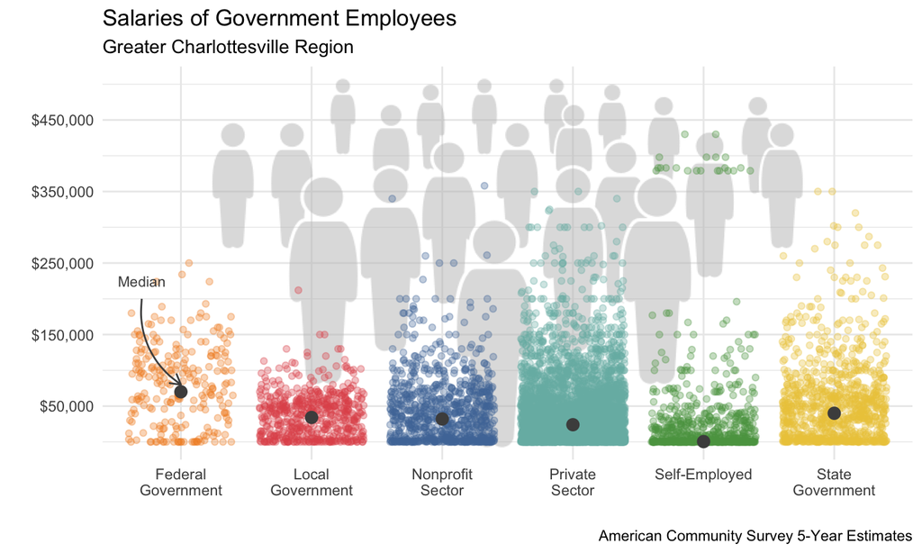

## Interactive viz

The [plotly package](https://cran.r-project.org/web/packages/plotly/index.html) provides a way of using the [plotly.js library](https://plotly.com/r/) within R

- By creating a plotly object with `plot_ly()`
- By transforming a ggplot object via `ggplotly()`

`ggplotly()` provides a lot of the functionality of `plot_ly()` without learning the details of `plot_ly()`. Because `ggplotly()` returns a `plot_ly()` object, though, it can be modified with additional `plot_ly()` options.

See [Carson Sievert’s book](https://plotly-r.com/) for more, especially [Chapter 2](https://plotly-r.com/overview) and [Chapter 33](https://plotly-r.com/improving-ggplotly)!

## plot_ly::ggplotly() example

[interactive chart not shown]

## Interactive tables

The [reactable package](https://glin.github.io/reactable/) provides a way of using the React Table JavaScript library within R

- Has interactive functionality (sorting, filtering) like DT::datatable()
- With more formatting and conditionaly styling like kableExtra

With additional and simplified formatting and customization provided in the [reactablefmtr package](https://kcuilla.github.io/reactablefmtr/).

## reactable::reactable() example

| Industry | Employees | Median Wages | Hours/ Week | % College Degree | % Private Sector |
| --- | --- | --- | --- | --- | --- |
| agr_for_fsh_hnt | 2708 | 13000 | 40 | 0.0110782865583456 | 0.0232644017725258 |
| min_qur_oil_gas | 246 | 55500 | 42 | 0.0121951219512195 | 0.040650406504065 |
| utilities | 1299 | 70000 | 40 | 0.0177059276366436 | 0.0346420323325635 |
| construction | 10321 | 28600 | 40 | 0.00746051739172561 | 0.0265478151341924 |
| manufacturing | 8165 | 39000 | 40 | 0.0186160440906307 | 0.0400489895897122 |
| wholesale | 1728 | 32250 | 40 | 0.025462962962963 | 0.0474537037037037 |
| retail | 15580 | 11700 | 36 | 0.0114890885750963 | 0.0436456996148909 |
| transport_warehouse | 5055 | 27500 | 40 | 0.00771513353115727 | 0.0280909990108803 |
| information | 2462 | 33400 | 40 | 0.0292445166531275 | 0.0304630381803412 |
| finance_insurance | 5674 | 48000 | 40 | 0.0281988015509341 | 0.0437081424039478 |

[output cut: 9 more lines]

## Don’t forget to comment your code!

[figure not shown]

## Let’s Play with R!

[figure not shown]